# Evaluate Water Temperature Trends

J Hagy

2024-04-25

##Temperature Trends in the Delaware River Generalized Additive Models (GAMs) were fitted to the long term water tempreature time series from the Delaware River to evaluate if water temperature has been changing.

### Load Data

```r
load(here("data","5.01 Delaware River at Penn Landing.Rdata"))
load(here("data","5. Chester_1961-2023.Rdata"))

df <- rbind(
  drChester_ctdo %>%
    select(date,wt.mean) %>%
    mutate(site="Chester"),
  drPenn_ctdo %>%
    select(date,wt.mean) %>%
    mutate(site="Penn Landing")
) %>%
  mutate(
    doy=yday(date),
    cyear=year(date)+doy/366,
    site=factor(site)
  ) %>%
  filter(!is.na(wt.mean))
```

### Fit a GAM to Water Temperature Data

The GAM explains 95% of the variability in water tempeature at the two sites in the fishery maintenance area of the Delaware River. Water Temperature at Penn Landing is about 0.5 degrees lower than at Chester. Overall water temperature deceased at the two sites; however, water temperature trends varied by season and by different periods within the overall time series.

```r
fit <- gam(wt.mean~site+s(cyear)+s(doy,bs="cc")+ti(cyear,doy),data=df)
summary(fit)
```

```
##
## Family: gaussian
## Link function: identity
##
## Formula:
## wt.mean ~ site + s(cyear) + s(doy, bs = "cc") + ti(cyear, doy)
##
## Parametric coefficients:
##                  Estimate Std. Error t value Pr(>|t|)
## (Intercept)      17.47865    0.01338 1306.55   <2e-16 ***
## sitePenn Landing -0.53000    0.01837  -28.85   <2e-16 ***
## ---
## Signif. codes:  0 '***' 0.001 '**' 0.01 '*' 0.05 '.' 0.1 ' ' 1
##
## Approximate significance of smooth terms:
##                  edf Ref.df        F p-value
## s(cyear)       8.941  8.999    76.91  <2e-16 ***
## s(doy)         7.687  8.000 76345.75  <2e-16 ***
## ti(cyear,doy) 15.768 15.990    68.33  <2e-16 ***
## ---
## Signif. codes:  0 '***' 0.001 '**' 0.01 '*' 0.05 '.' 0.1 ' ' 1
##
## R-sq.(adj) =  0.959   Deviance explained = 95.9%
## GCV = 2.6068  Scale est. = 2.604     n = 31145
```

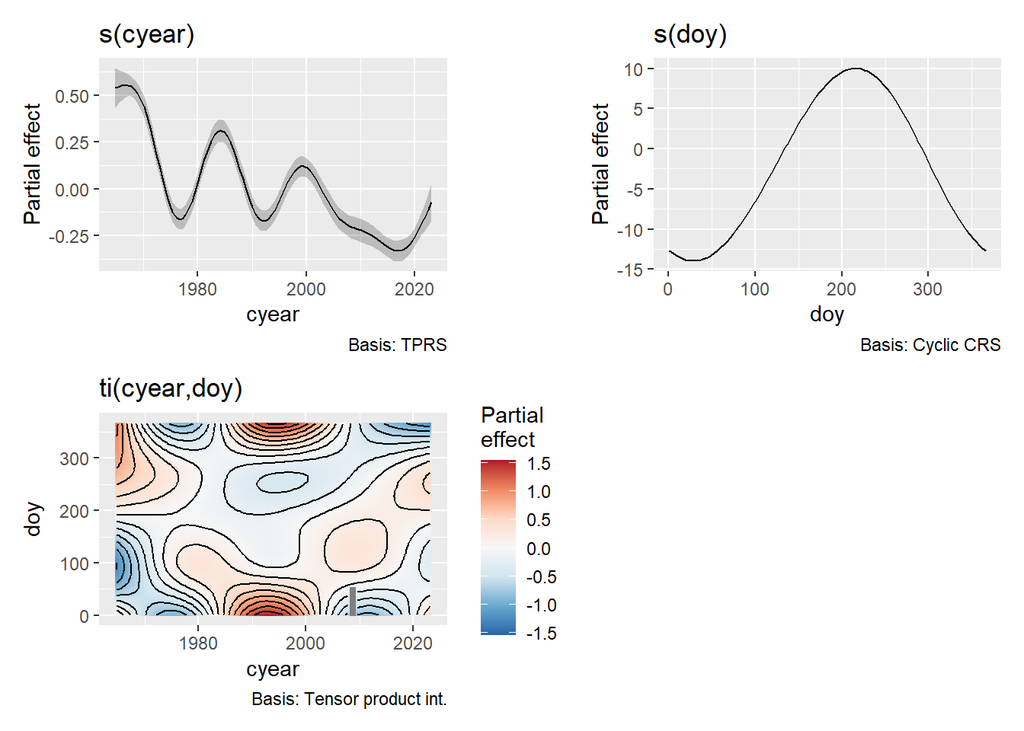

```r
draw(fit,rug=FALSE)
```

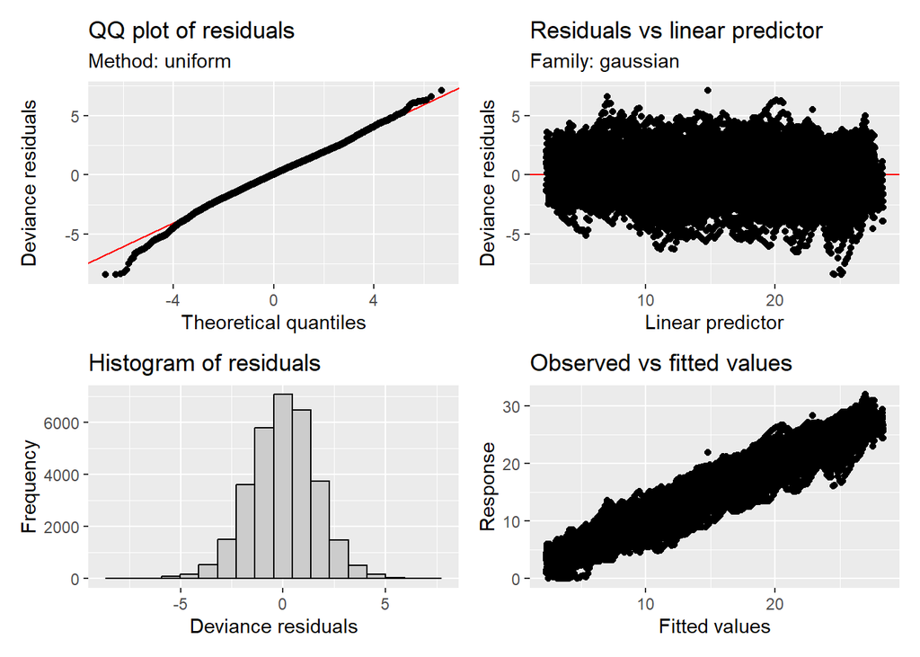

```r
appraise(fit)
```